# R Notebook

Due by end of day on 27 Jan 2021 Email your .R file to brian.beckage@uvm.edu with name as ‘pbio394_yourLastName_ex1.R’ and email header ‘pbio394 yourLastName Ex1’.

Below are a series of short exercises to become familiar with the basics of R.

1. Create a vector that is a sequence of from 1 to 100 and that is of length 200.

```r
myV<-seq(from=1,to=100,len=200)
myV
```

```
##   [1]   1.000000   1.497487   1.994975   2.492462   2.989950   3.487437
##   [7]   3.984925   4.482412   4.979899   5.477387   5.974874   6.472362
##  [13]   6.969849   7.467337   7.964824   8.462312   8.959799   9.457286
##  [19]   9.954774  10.452261  10.949749  11.447236  11.944724  12.442211
##  [25]  12.939698  13.437186  13.934673  14.432161  14.929648  15.427136
##  [31]  15.924623  16.422111  16.919598  17.417085  17.914573  18.412060
##  [37]  18.909548  19.407035  19.904523  20.402010  20.899497  21.396985
##  [43]  21.894472  22.391960  22.889447  23.386935  23.884422  24.381910
##  [49]  24.879397  25.376884  25.874372  26.371859  26.869347  27.366834
##  [55]  27.864322  28.361809  28.859296  29.356784  29.854271  30.351759
##  [61]  30.849246  31.346734  31.844221  32.341709  32.839196  33.336683
##  [67]  33.834171  34.331658  34.829146  35.326633  35.824121  36.321608
##  [73]  36.819095  37.316583  37.814070  38.311558  38.809045  39.306533
##  [79]  39.804020  40.301508  40.798995  41.296482  41.793970  42.291457
##  [85]  42.788945  43.286432  43.783920  44.281407  44.778894  45.276382
```

[output cut: 19 more lines]

2. Multiply each element in this list by 2 and find the sum of the resulting vector.

```r
sum(myV*2)
```

```
## [1] 20200
```

3. Square each element of this vector and find the summation of this transformed vector.

```r
sum(myV^2)
```

```
## [1] 675041.7
```

4. Select all elements of the transformed vector (from above) that are less than 50.

```r
myV<-seq(from=1,to=100,len=200)
myV<-myV^2
myV[myV<50]
```

```
##  [1]  1.000000  2.242469  3.979925  6.212368  8.939800 12.162218 15.879624
##  [8] 20.092018 24.799399 30.001768 35.699124 41.891467 48.578799
```

ADVANCED: Here is another way of doing this using the pipe operator that avoids intermediate expressions. If this doesn’t make sense, please ignore–its a bit advanced.

```r
library(magrittr)
seq(from=1,to=100,len=200) %>% .^2 %>% .[.<50]
```

```
##  [1]  1.000000  2.242469  3.979925  6.212368  8.939800 12.162218 15.879624
##  [8] 20.092018 24.799399 30.001768 35.699124 41.891467 48.578799
```

5. Create a 3 (rows) by 4 (cols) matrix of values 1:12

```r
myMat<-matrix(1:12,nrow=3,ncol=4)
myMat
```

```
##      [,1] [,2] [,3] [,4]
## [1,]    1    4    7   10
## [2,]    2    5    8   11
## [3,]    3    6    9   12
```

6. Multiple the component at the location [2,3] and the component at [3,2].

```r
myMat[2,3]*myMat[3,2]
```

```
## [1] 48
```

7. Name the rows (a,b,c) and the columns (1,2,3,4).

```r
rownames(myMat)<-c('a','b','c')
colnames(myMat)<-c('1','2','3','4')
myMat
```

```
##   1 2 3  4
## a 1 4 7 10
## b 2 5 8 11
## c 3 6 9 12
```

Alternative way

```r
dimnames(myMat)<-list(c('a','b','c'),c('1','2','3','4'))
myMat
```

```
##   1 2 3  4
## a 1 4 7 10
## b 2 5 8 11
## c 3 6 9 12
```

8. Create a 3 dimensional array that replicates the matrix created above three times in the 3rd dimension. Name the dimensions of the array.

```r
my3d<-array(c(rep(1:12,3)),dim=c(3,4,3))
dimnames(my3d)<-list(c('a','b','c'),c('1','2','3','4'),
                     c('1d','2d','3d'))
my3d
```

```
## , , 1d
##
##   1 2 3  4
## a 1 4 7 10
## b 2 5 8 11
## c 3 6 9 12
##
## , , 2d
##
##   1 2 3  4
## a 1 4 7 10
## b 2 5 8 11
## c 3 6 9 12
##
## , , 3d
##
##   1 2 3  4
## a 1 4 7 10
## b 2 5 8 11
## c 3 6 9 12
```

9. Multiply the 2nd row of the 2 dimension by the [3,3] element of the 3rd dimension.

```r
my3d[2,,2]*my3d[3,3,3]
```

```
##  1  2  3  4
## 18 45 72 99
```

10. Create a vector of 1,2 replicated to length 10.

```r
rep(c(1,2),5)
```

```
##  [1] 1 2 1 2 1 2 1 2 1 2
```

11. Create a vector of integers 1 to 10 and then create vectors that are the square and cube of that vector.

```r
myVect<-1:10
myVect^2
```

```
##  [1]   1   4   9  16  25  36  49  64  81 100
```

```r
myVect^3
```

```
##  [1]    1    8   27   64  125  216  343  512  729 1000
```

12. Create a data frame that combines these three vectors into the columns of a dataframe.

```r
myDataFrame<-data.frame(myVect,myVect^2,myVect^3)
head(myDataFrame)
```

|  | myVect | myVect.2 | myVect.3 |
| --- | --- | --- | --- |
| 1 | 1 | 1 | 1 |
| 2 | 2 | 4 | 8 |
| 3 | 3 | 9 | 27 |
| 4 | 4 | 16 | 64 |
| 5 | 5 | 25 | 125 |
| 6 | 6 | 36 | 216 |

ADVANCED: Here is another way of doing this using the pipe operator that avoids intermediate expressions. If this doesn’t make sense, please ignore–its a bit advanced.

```r
library(magrittr)
myVect %>% data.frame(.,.^2, .^3) -> myDataFrame
```

13. Name the columns of the data frame as: ‘Original’, ‘Squared’, and ‘Cubed’.

```r
colnames(myDataFrame)<-c('Original', 'Squared', 'Cubed')
```

14. Plot the original vs cubed columns.

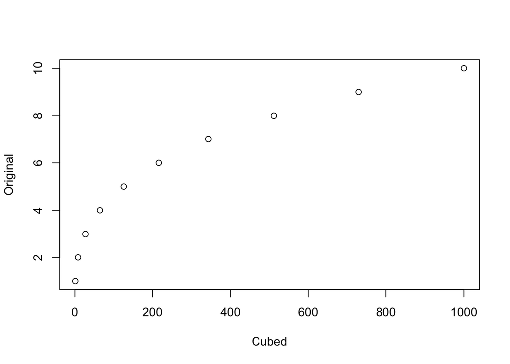

```r
plot(Original~Cubed,data=myDataFrame)
```

Advanced. Alternative method using Tidyverse dialect of R.

```r
library(dplyr)
```

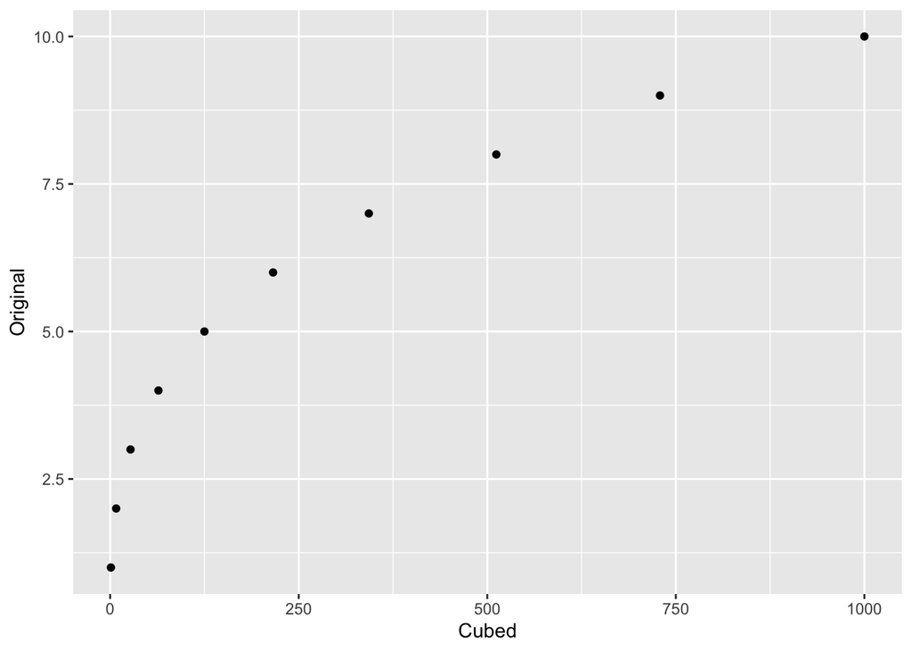

```r
library(magrittr)
library(ggplot2)
myDataFrame %>%
  select(Original, Cubed) %>%
  ggplot(aes(x = Cubed, y = Original)) +
  geom_point()
```

Below is some information on the use of R markdown used in this R notebook.